# PEC1_datos_omicos

Cristopher Valenzuela

10 de abril de 2021

El síndrome de Turner es un trastorno de aneuploidía de cromosoma X, utilizando los datos de perfiles de expresión de microarrays Objetivos: El objetivo de este análisis es, a partir de los datos de expresión detectados por microarrays, extraer un listado de genes diferencialmente expresados entre pacientes con síndrome de Turner, al comparar las muestras de sujetos control como sujetos con síndrome de Turner. Una vez con el listado de genes podemos determinar si la lista contiene genes asociados al fenotipo de la enfermedad de lo que esperaríamos por simple azar. Materiales y métodos: Muestras y datos de origen: El material biológico corresponde a un conjunto de datos de síndrome de Turner, cuyos datos de microarrays fueron obtenidos de ARNm aislado en sangre. Las muestras corresponden a pacientes con TS cuyo cromosoma X heredado es paterno (N = 6), TS cuyo cromosoma X heredado es materno (N = 6), además, una muestra correspondiente a sujetos sanos XX (N = 6). Las muestras de ARN total se aislaron de PBCM utilizando el mini kit Qiagen RNeasy (Qiagen), mientras que el ARNc biotinilado se prepararon usando el kit de transcripción in vitro (Affymetrix) a partir de 2 ug de ARN total. Las muestras fueron hibridadas con GeneChip Human U133 2.0 Plus (Affymetrix), y dichos datos fueron leídos con GeneChip Scanner 3000, para almacenarse utilizando Expression Console Versión 1.1 (Affymetrix). Los archivos .CEL que contienen la anotación de genes destacados fueron descargados de la página web Gene Expression Omnibus (GEO).

Diseño experimental Utilizaremos un conjunto de 18 ficheros. CEL procedentes cada uno de un microarray, se pueden clasificar según la condición de los pacientes según el origen parental del cromosoma X, si es de origen paterno, materno y los voluntarios sin el síndrome de Turner, por lo tanto, tenemos tres grupos, estos pacientes no se pueden asignar aleatoriamente ni tampoco su genotipo, debido a que es un estudio de carácter observacional, que podríamos tratar como un diseño de factor con 3 niveles, que corresponde al genotipo. Al no poder combinar las variables, podemos dividir las muestras en 3 grupos experimentales: 46XX_Normal 45Xm_Materno 45Xp_Paterno Las muestras “_Normal” contienen el genotipo XX y son pacientes voluntarios, por su parte “_Materno” indica pacientes cuyo cromosoma X es heredado por vía materna, mientras que “Paterno” indica que el cromosoma X es de origen paterno. Si comparamos las muestras “Normal-Materno-Paterno” entre sí, podríamos comparar la expresión diferencial entre las condiciones. En este caso realizamos las comparaciones de todos los grupos entre sí: Xp_Paterno-Xm_Materno XX_Normal-Xm_Materno Xp_Paterno-Xm_Materno - XX_Normal-Xm_Materno Comparamos los listados de genes obtenidos de los contrastes anteriores, y obtendremos listado de genes que se comportan de manera diferente entre sujetos que tienen cromosomas X heredado según origen parental y sujetos sin el síndrome (XX). Procedimiento para el análisis: 1. Identificar que grupos hay y a qué grupo pertenece cada muestra. 2. Exploración y control de calidad de los datos crudos 3. Normalización 4. [Control de calidad de los datos normalizados] (opcional) 5. Filtraje no específico [opcional] 6. Identificación de genes diferencialmente expresados 7. Anotación de los resultados 8. Comparación entre distintas comparaciones (si hay más de una comparación, ver que genes han sido seleccionados en más de una comparación) 9. Análisis de significación biológica (“Gene Enrichment Analysis”)

Selección de las muestras para el análisis Lo primero que debéis hacer es escoger las muestras que incluiréis en el estudio. Para ello debéis ejecutar el fragmento de código siguiente, pasando como argumento a la función vuestro número de identificación de la UOC (sin letras).

```r
myID <- 1062200
selectSamples<- function (myID){
set.seed(myID)
selected <- c(sample(1:10, 6),11, sample(12:26, 5), sample(27:36,6))
selected <- sort(selected)
}
```

Esta función os retornará 18 valores que utilizaréis para subsetear el objeto “targetsAll” creando vuestro targets propio. En el ejemplo ID es 1234567 y llamaos a nuestro objeto targets “myTargets”

```r
mySelected <- selectSamples(myID)
targetsAll <-read.csv(file="C:/Users/Cristopher/Desktop/datos omicos git/PEC1 datos omicos/data/targetsAll.csv", row.names = 1, head=TRUE)
myTargets <- targetsAll[mySelected,]
```

Este objeto “myTargets” os permitirá leer únicamente un subconjunto de 18 muestras (distinto para cada uno de vosotros) con el que realizaréis los análisis.

“Pipeline” de análisis Tal como habéis aprendido en esta unidad un análisis de microarrays suele seguir una serie de pasos ordenados. El proceso estándar consistirá en:

1. Identificar que grupos hay y a qué grupo pertenece cada muestra.

Podemos identificar 3 grupo

```r
targets <- read.csv2("C:/Users/Cristopher/Desktop/datos omicos git/PEC1 datos omicos/data/targetsAll.csv", header = TRUE, sep = ";")

targets$karyotype = as.factor(targets$karyotype)
targets$grupos = c(rep("46XX_Normal",6),rep("45Xm_Materno",6),rep("45Xp_Paterno",6))
targets$grupos = as.factor(targets$grupos)

knitr::kable(
   targets, booktabs = TRUE,
   caption = 'Content of the targets file used for the current analysis')
```

Content of the targets file used for the current analysis

| X | title | karyotype | grupos |
| --- | --- | --- | --- |
| GSM1134016 | XX_rep1 | 46XX | 46XX_Normal |
| GSM1134019 | XX_rep4 | 46XX | 46XX_Normal |
| GSM1134020 | XX_rep5 | 46XX | 46XX_Normal |
| GSM1134021 | XX_rep6 | 46XX | 46XX_Normal |
| GSM1134023 | XX_rep8 | 46XX | 46XX_Normal |
| GSM1134025 | XX_rep10 | 46XX | 46XX_Normal |
| GSM1134026 | Xm_rep1 | 45Xm | 45Xm_Materno |
| GSM1134028 | Xm_rep3 | 45Xm | 45Xm_Materno |
| GSM1134029 | Xm_rep4 | 45Xm | 45Xm_Materno |
| GSM1134030 | Xm_rep5 | 45Xm | 45Xm_Materno |
| GSM1134040 | Xm_rep15 | 45Xm | 45Xm_Materno |
| GSM1134041 | Xm_rep16 | 45Xm | 45Xm_Materno |
| GSM1134043 | Xp_rep2 | 45Xp | 45Xp_Paterno |
| GSM1134045 | Xp_rep4 | 45Xp | 45Xp_Paterno |
| GSM1134046 | Xp_rep5 | 45Xp | 45Xp_Paterno |
| GSM1134047 | Xp_rep6 | 45Xp | 45Xp_Paterno |
| GSM1134049 | Xp_rep8 | 45Xp | 45Xp_Paterno |
| GSM1134051 | Xp_rep10 | 45Xp | 45Xp_Paterno |

2. Exploración y control de calidad de los datos crudos

Leer archivos CEL, lo datos brutos y los almacenamos en una variable "rawData", cargamos primero el paquete "oligo" para leer estos archivos.

```r
library(oligo)
celFiles <- list.celfiles("C:/Users/Cristopher/Desktop/datos omicos git/PEC1 datos omicos/data", full.names = TRUE)
library(Biobase)
my.targets <-read.AnnotatedDataFrame(file.path("C:/Users/Cristopher/Desktop/datos omicos git/PEC1 datos omicos/data","targetsAll.csv"),
                                      header = TRUE, row.names = 1,
                                      sep=";")

rawData <- read.celfiles(celFiles, phenoData = my.targets)
```

```
## Platform design info loaded.
```

[output not shown]

```r
my.targets@data$title ->rownames(pData(rawData))
colnames(rawData) <-rownames(pData(rawData))

head(rawData)
```

```
## ExpressionFeatureSet (storageMode: lockedEnvironment)
## assayData: 6 features, 18 samples
##   element names: exprs
## protocolData
##   rowNames: XX_rep1 XX_rep4 ... Xp_rep10 (18 total)
##   varLabels: exprs dates
##   varMetadata: labelDescription channel
## phenoData
##   rowNames: XX_rep1 XX_rep4 ... Xp_rep10 (18 total)
##   varLabels: title karyotype
##   varMetadata: labelDescription channel
## featureData: none
## experimentData: use 'experimentData(object)'
## Annotation: pd.hg.u133.plus.2
```

Control de calidad

```r
#library(arrayQualityMetrics)
#arrayQualityMetrics(rawData)
```

```r
 library(ggplot2)
 library(ggrepel)
 plotPCA3 <- function (datos, labels, factor, title, scale,colores, size = 1.5, glineas = 0.25) {
   data <- prcomp(t(datos),scale=scale)
   # plot adjustments
   dataDf <- data.frame(data$x)
   Group <- factor
   loads <- round(data$sdev^2/sum(data$sdev^2)*100,1)
   # main plot
   p1 <- ggplot(dataDf,aes(x=PC1, y=PC2)) +
     theme_classic() +
     geom_hline(yintercept = 0, color = "gray70") +
     geom_vline(xintercept = 0, color = "gray70") +
     geom_point(aes(color = Group), alpha = 0.55, size = 3) +
     coord_cartesian(xlim = c(min(data$x[,1])-5,max(data$x[,1])+5)) +
     scale_fill_discrete(name = "Group")
   # avoiding labels superposition
   p1 + geom_text_repel(aes(y = PC2 + 0.25, label = labels),segment.size = 0.25, size = size) +
     labs(x = c(paste("PC1",loads[1],"%")),y=c(paste("PC2",loads[2],"%"))) +
     ggtitle(paste("Principal Component Analysis for: ",title,sep=" "))+
     theme(plot.title = element_text(hjust = 0.5)) +
     scale_color_manual(values=colores)
   }
```

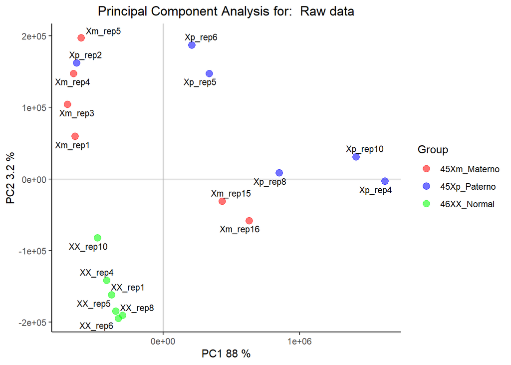

```r
plotPCA3(exprs(rawData), labels = targets$title, factor = targets$grupos,
          title="Raw data", scale = FALSE, size = 3,
          colores = c("red", "blue", "green"))
```

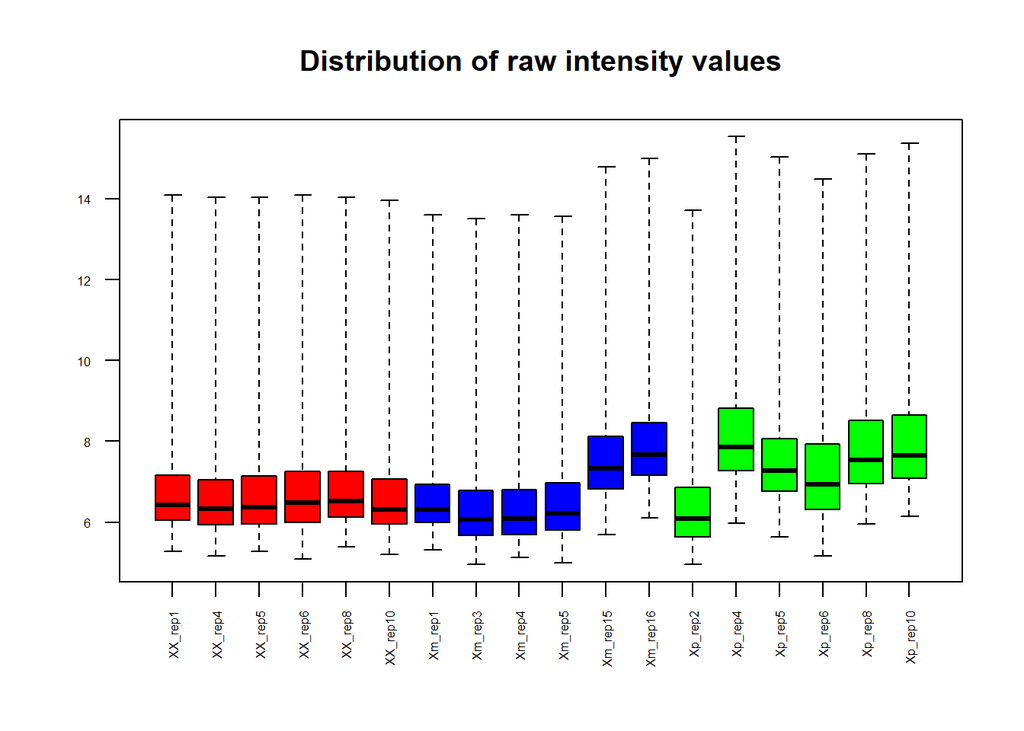

```r
boxplot(rawData, cex.axis=0.5, las=2,  which="all",
          col = c(rep("red", 6), rep("blue", 6), rep("green", 6)),
          main="Distribution of raw intensity values")
```

Data normalization

```r
eset_rma <- rma(rawData)
```

```
## Background correcting
## Normalizing
## Calculating Expression
```

Quality control of normalized data

```r
library(arrayQualityMetrics)
arrayQualityMetrics(eset_rma, outdir = file.path("./results", "QCDir.Norm"), force=TRUE)
```

```
## The report will be written into directory './results/QCDir.Norm'.
```

[output not shown]

```
## (loaded the KernSmooth namespace)
```

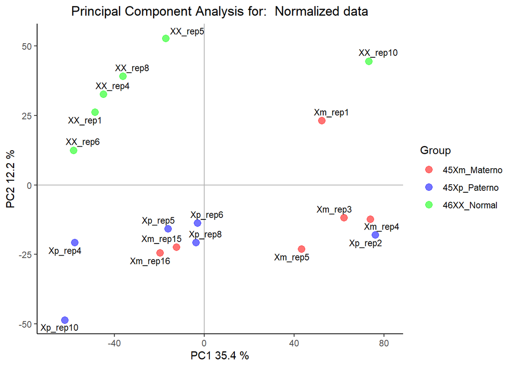

```r
plotPCA3(exprs(eset_rma), labels = targets$title, factor = targets$grupos,
          title="Normalized data", scale = FALSE, size = 3,
          colores = c("red", "blue", "green"))
```

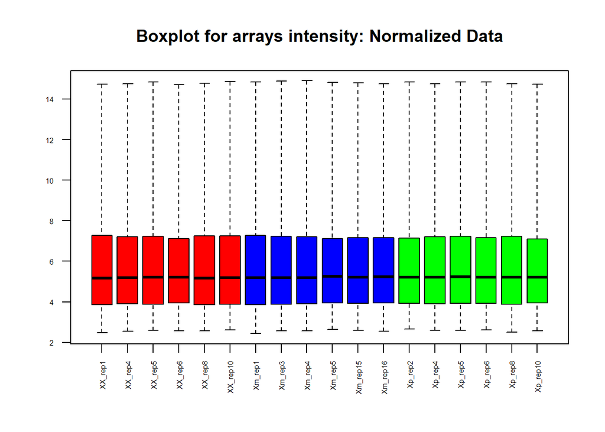

```r
boxplot(eset_rma, cex.axis=0.5, las=2,  which="all",
          col = c(rep("red", 6), rep("blue", 6), rep("green", 6)),
          main="Boxplot for arrays intensity: Normalized Data")
```

Detecting most variable genes

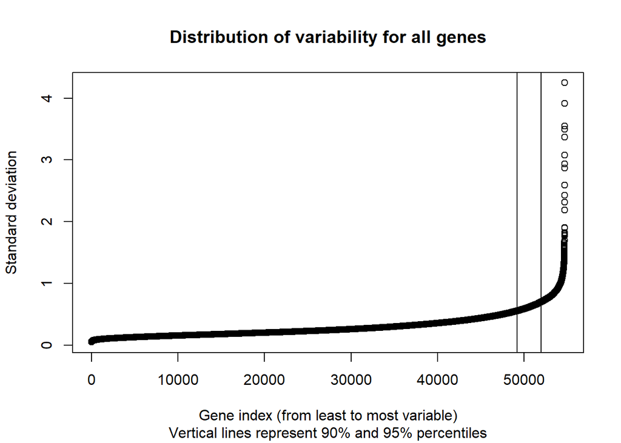

```r
sds <- apply (exprs(eset_rma), 1, sd)
sdsO<- sort(sds)
plot(1:length(sdsO), sdsO, main="Distribution of variability for all genes",
      sub="Vertical lines represent 90% and 95% percentiles",
      xlab="Gene index (from least to most variable)", ylab="Standard deviation")
 abline(v=length(sds)*c(0.9,0.95))
```

Filtering least variable genes

```r
library(genefilter)

library(org.Hs.eg.db)
annotation(eset_rma) <- "org.Hs.eg.db"

filtered <- nsFilter(eset_rma,
                      require.entrez = TRUE, remove.dupEntrez = TRUE,
                      var.filter=TRUE, var.func=IQR, var.cutoff=0.75,
                      filterByQuantile=TRUE, feature.exclude = "^AFFX")

print(filtered$filter.log)
```

```
## $numDupsRemoved
## [1] 0
##
## $numLowVar
## [1] 40960
##
## $feature.exclude
## [1] 62
##
## $numRemoved.EG
## [1] 0
```

```r
eset_filtered <-filtered$eset
```

Saving normalized and filtered data

```r
write.csv(exprs(eset_rma), file="./results/normalized.Data.csv")
write.csv(exprs(eset_filtered), file="./results/normalized.Filtered.Data.csv")
save(eset_rma, eset_filtered, file="./results/normalized.Data.Rda")
```

Defining the experimental setup: The design matrix

```r
if (!exists("eset_filtered")) load (file="./results/normalized.Data.Rda")

library(limma)
library(stringr)

 design2<- model.matrix(~0+targets$grupos,pData(eset_filtered))
 colnames(design2) <- c("Xm_Materno","Xp_Paterno","XX_Normal")
 print(design2)
```

```
##          Xm_Materno Xp_Paterno XX_Normal
## XX_rep1           0          0         1
## XX_rep4           0          0         1
## XX_rep5           0          0         1
## XX_rep6           0          0         1
## XX_rep8           0          0         1
## XX_rep10          0          0         1
## Xm_rep1           1          0         0
## Xm_rep3           1          0         0
## Xm_rep4           1          0         0
## Xm_rep5           1          0         0
## Xm_rep15          1          0         0
## Xm_rep16          1          0         0
## Xp_rep2           0          1         0
## Xp_rep4           0          1         0
## Xp_rep5           0          1         0
## Xp_rep6           0          1         0
## Xp_rep8           0          1         0
## Xp_rep10          0          1         0
## attr(,"assign")
## [1] 1 1 1
## attr(,"contrasts")
## attr(,"contrasts")$`targets$grupos`
## [1] "contr.treatment"
```

Ahora podemos definir las comparaciones de entre los "cariotipos" en dos en dos o dicho de otra manera cada uno contra el otro.

Defining comparisons with the Contrasts Matrix

```r
cont.matrix <- makeContrasts (PaternovsMaterno = Xp_Paterno-Xm_Materno,
                              NormalvsMaterno = XX_Normal-Xm_Materno,
                               INT = (Xp_Paterno-Xm_Materno) - (XX_Normal-Xm_Materno),
                               levels=design2)
print(cont.matrix)
```

```
##             Contrasts
## Levels       PaternovsMaterno NormalvsMaterno INT
##   Xm_Materno               -1              -1   0
##   Xp_Paterno                1               0   1
##   XX_Normal                 0               1  -1
```

Model estimation and gene selection

```r
library(limma)
fit<-lmFit(eset_filtered, design2)
fit.main<-contrasts.fit(fit, cont.matrix)
fit.main<-eBayes(fit.main)
class(fit.main)
```

```
## [1] "MArrayLM"
## attr(,"package")
## [1] "limma"
```

Obtaining lists of differentially expressed gene

```r
topTab_PaternovsMaterno <- topTable (fit.main, number=nrow(fit.main), coef="PaternovsMaterno", adjust="fdr")
head(topTab_PaternovsMaterno)
```

```
##                 logFC  AveExpr        t      P.Value adj.P.Val         B
## 209307_at   1.0967429 7.676046 4.415781 0.0002399363 0.4530471 -1.629585
## 236831_at   1.0845450 3.920977 4.390958 0.0002546068 0.4530471 -1.652546
## 217148_x_at 1.4435728 9.627186 4.110461 0.0004980935 0.4530471 -1.916727
## 228377_at   1.2450794 6.282142 4.093911 0.0005182094 0.4530471 -1.932571
## 207655_s_at 1.0560406 8.247097 4.091262 0.0005215032 0.4530471 -1.935109
## 210347_s_at 0.8299795 8.492904 4.052602 0.0005720218 0.4530471 -1.972233
```

2 comparacion

```r
topTab_NormalvsMaterno <- topTable (fit.main, number=nrow(fit.main), coef="NormalvsMaterno", adjust="fdr")
head(topTab_NormalvsMaterno)
```

```
##                logFC  AveExpr        t      P.Value    adj.P.Val        B
## 214218_s_at 6.848228 5.701082 34.48829 5.463461e-20 7.459263e-16 27.36488
## 227671_at   7.924364 6.474132 33.34960 1.093224e-19 7.462894e-16 27.09794
## 224589_at   5.962863 5.223378 31.71790 3.077027e-19 1.400355e-15 26.67881
## 224590_at   7.204480 5.564498 30.63331 6.299841e-19 2.150293e-15 26.37368
## 221728_x_at 6.967197 6.693064 26.02656 1.779949e-17 4.860329e-14 24.78573
## 224588_at   8.323715 7.625700 17.73219 4.022191e-14 9.152496e-11 20.07367
```

La tercera comparacion con INT

```r
topTab_INT  <- topTable (fit.main, number=nrow(fit.main), coef="INT", adjust="fdr")
head(topTab_INT)
```

```
##                 logFC  AveExpr         t      P.Value    adj.P.Val        B
## 214218_s_at -7.004664 5.701082 -35.27612 3.424711e-20 4.369503e-16 26.54132
## 227671_at   -8.132394 6.474132 -34.22510 6.400795e-20 4.369503e-16 26.33032
## 224589_at   -6.103491 5.223378 -32.46594 1.902833e-19 8.659794e-16 25.94213
## 224590_at   -7.362189 5.564498 -31.30389 4.033679e-19 1.376796e-15 25.65881
## 221728_x_at -7.324553 6.693064 -27.36150 6.401794e-18 1.748074e-14 24.50238
## 224588_at   -8.807153 7.625700 -18.76207 1.313369e-14 2.988571e-11 20.34470
```

Gene anotattion

```r
 annotatedTopTable <- function(topTab, anotPackage)
 {
  topTab <- cbind(PROBEID=rownames(topTab), topTab)
  myProbes <- rownames(topTab)
  thePackage <- eval(parse(text = anotPackage))
  geneAnots <- select(thePackage, myProbes, c("SYMBOL", "ENTREZID", "GENENAME"))
  annotatedTopTab<- merge(x=geneAnots, y=topTab, by.x="PROBEID", by.y="PROBEID")
 return(annotatedTopTab)
 }

library(hgu133plus2.db)
 topAnnotated_PaternovsMaterno <- annotatedTopTable(topTab_PaternovsMaterno,
                                                    anotPackage="hgu133plus2.db")
topAnnotated_NormalvsMaterno <- annotatedTopTable(topTab_NormalvsMaterno,
                                                  anotPackage="hgu133plus2.db")
topAnnotated_INT <- annotatedTopTable(topTab_INT,
                                      anotPackage="hgu133plus2.db")
write.csv(topAnnotated_PaternovsMaterno, file="./results/topAnnotated_PaternovsMaterno.csv")
write.csv(topAnnotated_NormalvsMaterno, file="./results/topAnnotated_NormalvsMaterno.csv")
write.csv(topAnnotated_INT, file="./results/topAnnotated_INT.csv")
```

Visualizing differential expression

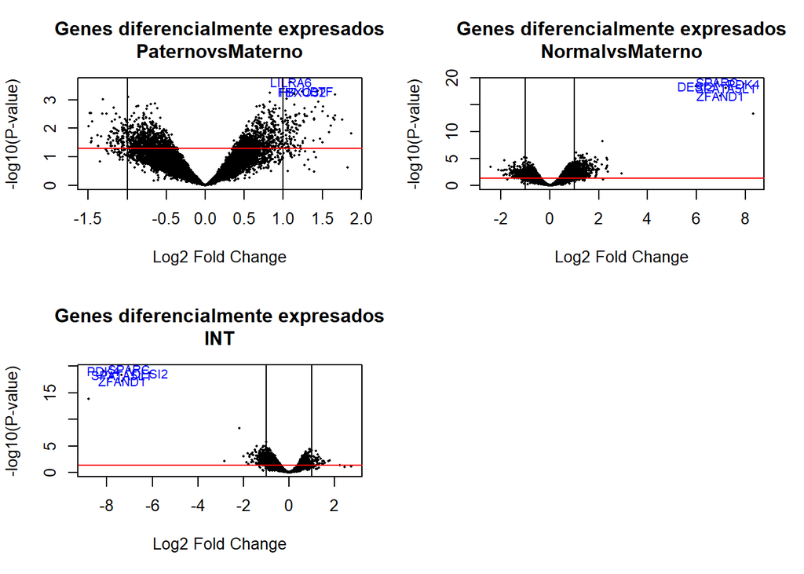

```r
par(mfrow=c(2, 2))
contrastes <- colnames(fit.main$coefficients)
for (contrast in 1:length(contrastes)){
  volcanoplot(fit.main,
              coef = contrastes[contrast],
              highlight = 5,
              names = eval(str2expression(
                paste0("topAnnotated_", contrastes[contrast], "$SYMBOL"))),
              main=paste("Genes diferencialmente expresados", contrastes[contrast],
                         sep = "\n"))
abline(v=c(-1,1))
abline(h=-log10(0.05), col="red")
}
```

Comparaciones multiples

```r
library(limma)
res<-decideTests(fit.main, method="separate", adjust.method="fdr", p.value=0.1, lfc=1)

sum.res.rows<-apply(abs(res),1,sum)
res.selected<-res[sum.res.rows!=0,]
print(summary(res))
```

```
##        PaternovsMaterno NormalvsMaterno   INT
## Down                  0             179    96
## NotSig            13653           13097 13548
## Up                    0             377     9
```

Diagrama de Venn

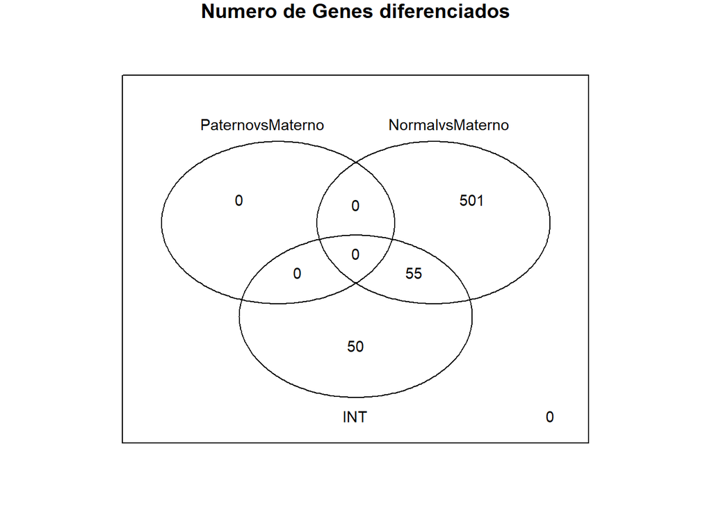

```r
vennDiagram (res.selected[,1:3], main="Numero de Genes diferenciados", cex=0.9)
```

Creamos una tabla con las anotaciones disponibles para los genes seleccionados en la sección de comparaciones múltiples:

```r
require(annaffy)
genesSelected <- rownames(res.selected)
at <- aafTableAnn(genesSelected, "hgu133plus2.db")
saveHTML (at, file="results/anotations.html",
          "Annotations for selected genes")
```

heatsmap

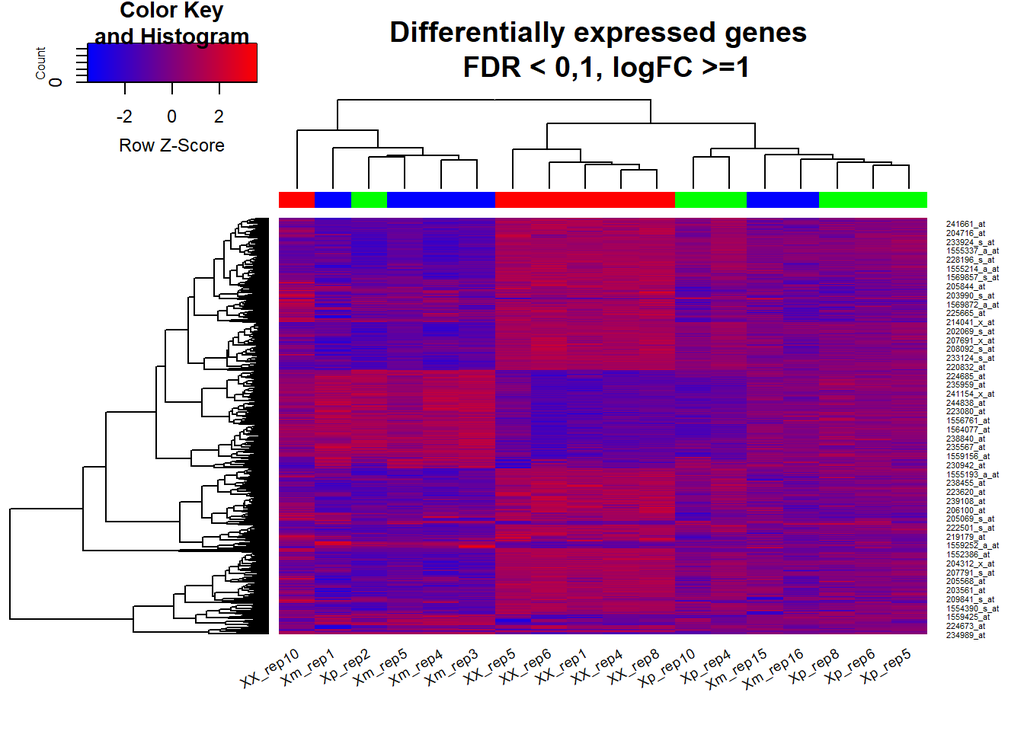

```r
probesInHeatmap <- rownames(res.selected)
HMdata <- exprs(eset_filtered)[rownames(exprs(eset_filtered)) %in% probesInHeatmap,]
write.csv(HMdata, file = file.path("./results/data4Heatmap.csv"))
my_palette <- colorRampPalette(c("blue", "red"))(n = 299)
library(gplots)
heatmap.2(HMdata,
           Rowv = TRUE,
           Colv = TRUE,
           dendrogram = "both",
           main = "Differentially expressed genes \n FDR < 0,1, logFC >=1",
           scale = "row",
           col = my_palette,
           sepcolor = "white",
           sepwidth = c(0.05,0.05),
           cexRow = 0.5,
           cexCol = 0.9,
           key = TRUE,
           keysize = 1.5,
           density.info = "histogram",
           ColSideColors = c(rep("red",6),rep("blue",6), rep("green",6)),
           tracecol = NULL,
           srtCol = 30)
```

significación biológica

```r
library(hgu133plus2.db)

listOfTables <- list(ControlvsMaterno = topTab_NormalvsMaterno,
                     INT_c = topTab_INT)
listOfSelected <- list()
 for (i in 1:length(listOfTables)){
   # select the toptable
   topTab <- listOfTables[[i]]
   # select the genes to be included in the analysis
   whichGenes<-topTab["adj.P.Val"]<0.20
   selectedIDs <- rownames(topTab)[whichGenes]
   # convert the ID to Entrez
   EntrezIDs<- select(hgu133plus2.db, selectedIDs, c("ENTREZID"))
   EntrezIDs <- EntrezIDs$ENTREZID
   listOfSelected[[i]] <- EntrezIDs
   names(listOfSelected)[i] <- names(listOfTables)[i]
 }
 sapply(listOfSelected, length)
```

```
## ControlvsMaterno            INT_c
##             5183             1451
```

```r
require(AnnotationDbi)
library(topGO)
```

```r
mapped_genes2GO <-  mappedkeys(org.Hs.egGO)
mapped_genes2KEGG <- mappedkeys(org.Hs.egPATH)
mapped_genes <- union(mapped_genes2GO , mapped_genes2KEGG)
```

```r
library(ReactomePA)
```

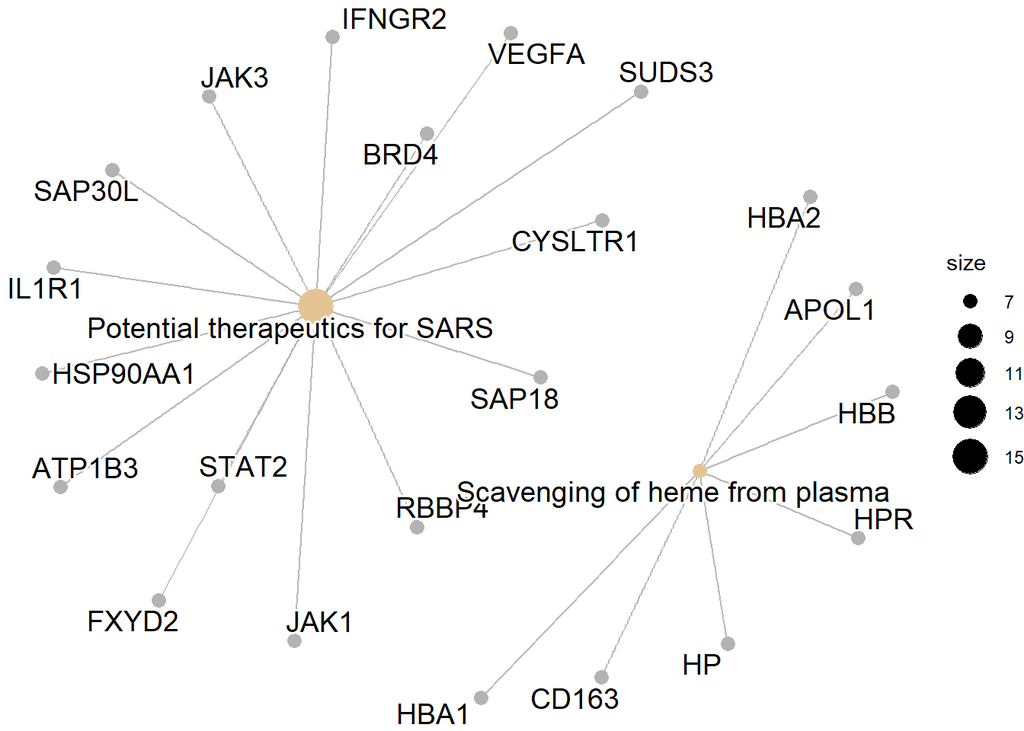

```r
library(ggnewscale)
library(ggplot2)
require(AnnotationDbi)
 listOfData <- listOfSelected[1:2]
 comparisonsNames <- names(listOfData)
 universe <- mapped_genes

 for (i in 1:length(listOfData)){
   genesIn <- listOfData[[i]]
   comparison <- comparisonsNames[i]
   enrich.result <- enrichPathway(gene = genesIn,
                                  pvalueCutoff = 0.05,
                                  readable = TRUE,
                                  pAdjustMethod = "BH",
                                  organism = "human",
                                  universe = universe
                                  )


   if (length(rownames(enrich.result@result)) != 0) {
     write.csv(as.data.frame(enrich.result),
              file =paste0("./results/","ReactomePA.Results.",comparison,".csv"),
              row.names = FALSE)

   pdf(file=paste0("./results/","ReactomePABarplot.",comparison,".pdf"))
     print(barplot(enrich.result, showCategory = 15, font.size = 4,
             title = paste0("Reactome Pathway Analysis for ", comparison,". Barplot")))
   dev.off()

   pdf(file = paste0("./results/","ReactomePAcnetplot.",comparison,".pdf"))
     print(cnetplot(enrich.result, categorySize = "geneNum", schowCategory = 15,
          vertex.label.cex = 0.75))
   dev.off()
   }
 }
  cnetplot(enrich.result, categorySize = "geneNum", schowCategory = 15,
          vertex.label.cex = 0.60)
```